# Central Limit Theorem simulation with exponential distribution

X. Zeng

August 18, 2015

## Overview

In this report, we will use exponential distribution to verify the Central Limit Theorm (CLT). In probability theory, the CLT states that, given certain conditions, the arithmetic mean of a sufficiently large number of iterates of independent random variables, each with a well-defined expected value and well-defined variance, will be approximately normally distributed, regardless of the underlying distribution.

We will investigate the distribution of averages of 40 exponentials with lamda=0.2 for all the simulation. The mean of exponential distribution is 1/lambda and the standard deviation is also 1/lambda. ## Simulations First, we need to set up the parameters for lamda, the total number of simulations `n=1000` and average number `m=40`

```r
set.seed(12345)
lamda <- 0.2
n <- 1000
m <- 40
```

Then, we show the distribution of exponentail numbers:

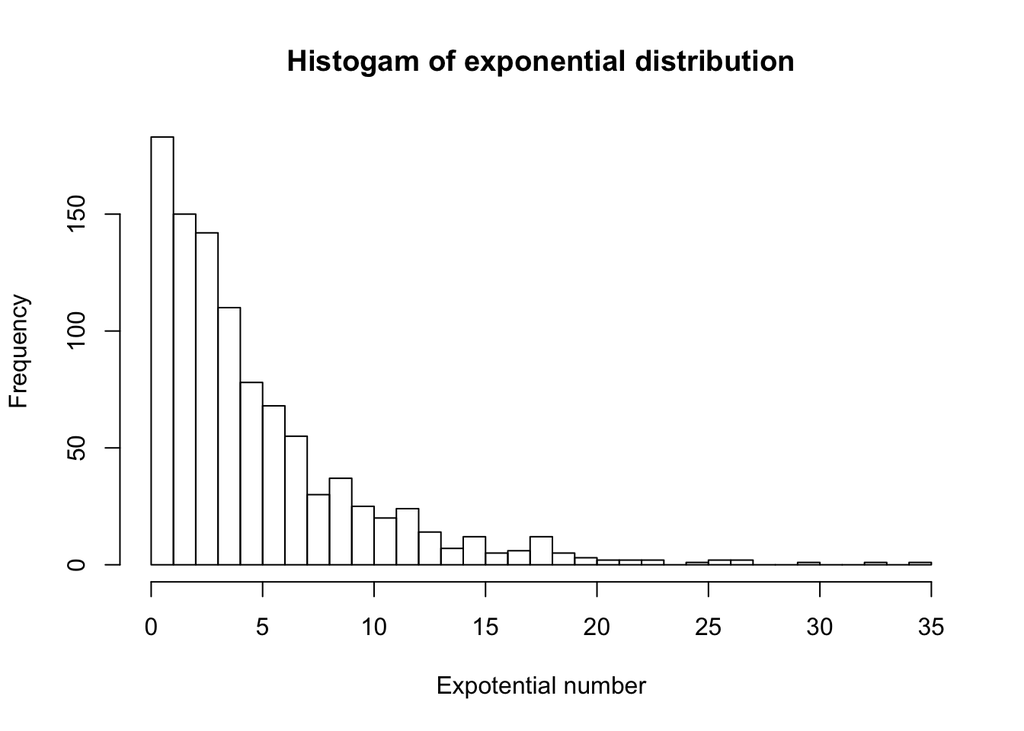

```r
hist(rexp(n, lamda), breaks=40,
      xlab="Expotential number", ylab="Frequency",
      main="Histogam of exponential distribution")
```

Here, we will generate the average 40 exponentials with 1000 simulations.

```r
mns = NULL
for (i in 1:n) {
  mns = c(mns, mean(rexp(m, lamda)))
}
```

## Sample Mean versus Theoretical Mean

Here shows the histogram of the simulated numbers `mns` with sample mean 4.9770396 (denoted by red line) and theoretical mean 5 (denoted by blue line). As we can see, they are quite close.

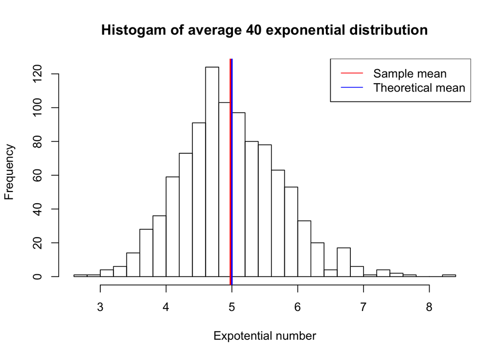

```r
hist(mns, breaks=40, xlab="Expotential number", ylab="Frequency",
     main="Histogam of average 40 exponential distribution")
abline(v=mean(mns),col="red", lwd=2)
abline(v=1/lamda, col="blue", lwd=2)
legend("topright",c("Sample mean", "Theoretical mean"), col=c("red","blue"),
       lty=c(1,1))
```

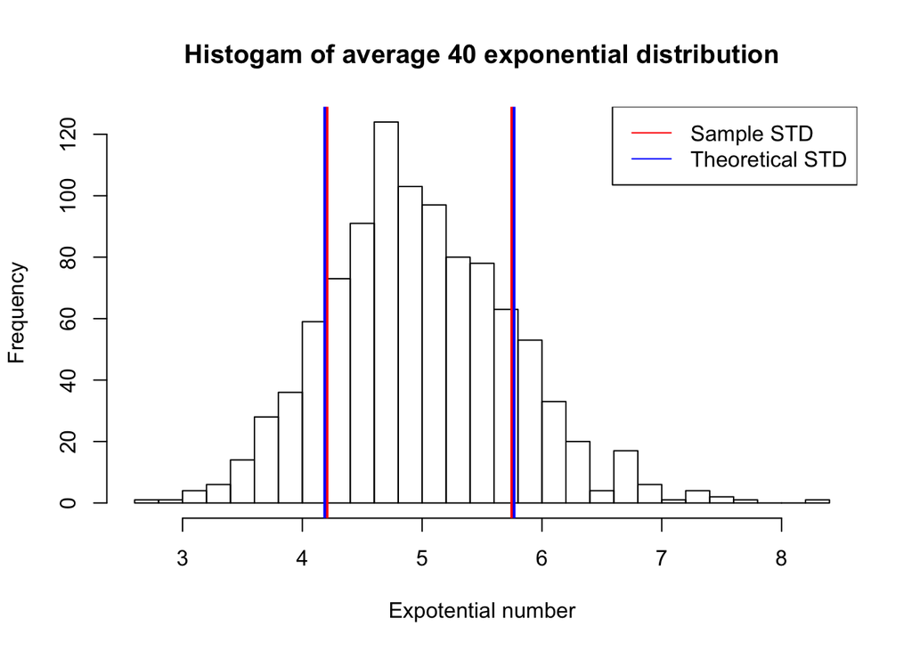

```r
hist(mns, breaks=40, xlab="Expotential number", ylab="Frequency",
     main="Histogam of average 40 exponential distribution")
abline(v=mean(mns)-sd(mns),col="red", lwd=2)
abline(v=mean(mns)+sd(mns),col="red", lwd=2)
abline(v=mean(mns)-1/lamda/sqrt(m), col="blue", lwd=2)
abline(v=mean(mns)+1/lamda/sqrt(m), col="blue", lwd=2)
legend("topright",c("Sample STD", "Theoretical STD"), col=c("red","blue"),
       lty=c(1,1))
```

## Distribution From the above histogram, we can see gengenraly the distribution is quite similar as the norm distribution. So we calcualte the density and add the theoretical (blue) and simple density lines (red). The theoretical norm distribution is simply $N(1/lamda, 1/(lamda^2 * m))$.

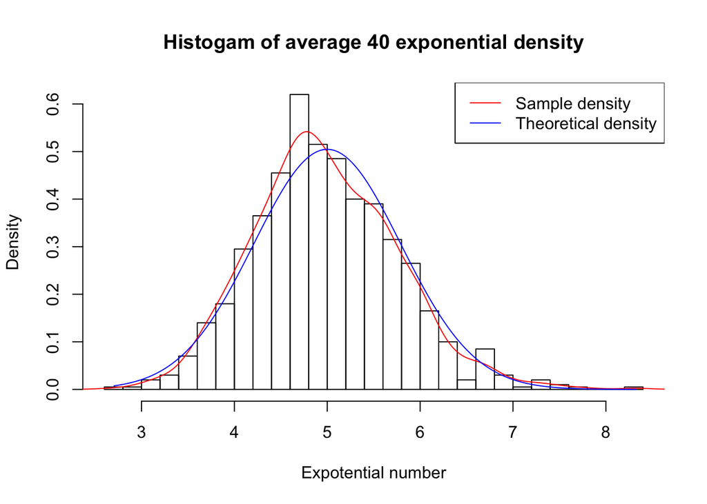

```r
hist(mns, breaks=40, prob=TRUE, xlab="Expotential number", ylab="Density",
     main="Histogam of average 40 exponential density")
lines(density(mns),col="red")
lines(seq(min(mns),max(mns),length=n),
      dnorm(seq(min(mns),max(mns),length=n),mean=1/lamda,sd=1/lamda/sqrt(m)),col="blue")
legend("topright",c("Sample density", "Theoretical density"), col=c("red","blue"),
       lty=c(1,1))
```

From the quantile plot comparison, we can see the distribution generally is a norm distribution.

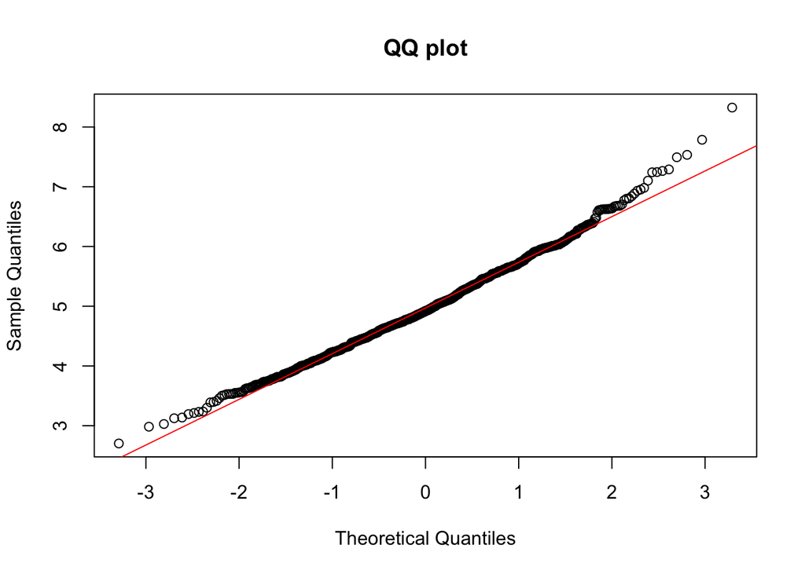

```r
qqnorm(mns, main="QQ plot")
qqline(mns, col="red")
```